# **Intro Chemistry I**

## [*Prepared by A. G. Hossion*](https://www.researchgate.net/profile/Abu-Gafar-Hossion)

[figure not shown]

# Chapter 1

## *Basic Concepts About Matter*

[Cengage Chapter 1 Link on Canvas](https://bridgeport.instructure.com/courses/2177365/modules/items/46775380)

[Lecture ppt slides Link](https://drive.google.com/file/d/1GIoyjiuBAkGnzWLMITUrqtlMIGQub8Qr/view?usp=sharing)

[Click Here to watch Solid-Liquid-Gas video demo](https://app.screencast.com/Tn1G9e4tbd133)

[figure not shown]

- **Chemistry, Matter, Physical States of Matter**. What is chemistry? What is matter? Know the three physical states of matter and be able to define the differences between them.
- [**Physical versus Chemical changes**.](https://app.screencast.com/9ZQwBGCJPm9c8) Be able to make the distinctions between physical properties versus chemical properties and physical change versus chemical change.
- **Classification of Matter**. Know the differences between a pure substance versus a mixture, and an element versus a compound.
- Understand what is **element, atoms, chemical symbol, molecules (homoatomic), compounds (heteroatomic), pure substance, mixture (homogenous/heterogenous), chemical symbol, chemical formula**.

## Concept Checks and/or Class Practice

### [**Cengage Chapter 1 electronic online h.w. on Canvas topics:**](https://bridgeport.instructure.com/courses/2177365/assignments/21601001)

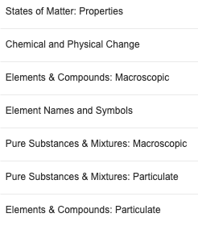

# **Chapter 2**

## *Measurements in Chemistry*

[Cengage Chapter 2 Link on Canvas](https://bridgeport.instructure.com/courses/2177365/modules/items/46775383)

[Lecture ppt Slides Link](https://drive.google.com/file/d/1cAdp9a14mQv8w58tiRdyrgxml6yXktPS/view?usp=sharing)

[Click Here to watch Density ia an intensive property](https://app.screencast.com/Hevu9lcL7ZSJT)

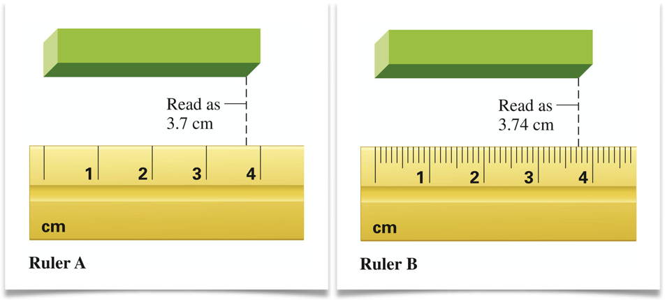

- **Measurements, Metric System.** Understand the importance of including a unit with a measured or calculated value in science. Be familiar with the metric system of units and prefixes. Know how to convert between the name, the prefix, and the power of ten without any help for these six prefixes: mega (M), kilo (K), deci (d), centi (c), milli (m), micro (μ).
- **Significant Figures.** Be able to recognize an exact number. Understand that every measurement has a certain level of uncertainty associated with it. Be able to determine the proper number of significant digits in: (a) a number in decimal notation; (b) a number in scientific notation; or (c) an answer to a series of mathematical calculations.
- **Exponents/Scientific Notation.** Know how to interpret scientific notation and be able to interconvert any number between decimal notation and scientific notation.
- [**Conversion Factors/Dimensional Analysis.**](https://app.screencast.com/pE5lu0rYxDn7n) Be able to use conversion factors to convert from one unit to another unit. Know how to use dimensional analysis to help set up and check your calculations. Temperature. Understand the Celsius and Kelvin temperature scales. You should memorize the conversion factor to interconvert between these two scales.
- **Density.** Understand how density is calculated. Be able to use density as a conversion factor to interconvert between mass and volume.

## Concept Check and/or Class Practice

- What system of measurement is used in scientific work? (a) English system (b) European system (c) Metric system (d) Science system.
- Which of the following represents the largest measurement of mass of an object? (a) Gram (b) Microgram (c) Nanogram (d) Kilogram.
- Which of the following statements is true? (a) An exact number is a number that has no uncertainty associated with it. (b) An inexact number is a number that has a degree of uncertainty associated with it. (c) Inexact numbers occur any time a measurement is made. (d) All of these.
- Which types of zeros in a number are considered significant? (a) Leading and confined zeros (b) Leading and trailing zeros (c) Confined and trailing zeros (d) Leading, confined, and trailing zeros.
- Read the length of the metal bar with the correct number of significant figures.

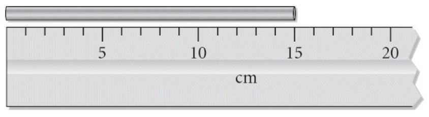

(a) 20 cm (b) 15 cm (c) 15.0 cm (d) 15.00 cm (e) 15.000 cm.

- how many Significant figures in 1006.00, 10060, 0.0060, 1006 ?
- A calculator gives an answer of 8.8274 when you multiply 4.60 by 1.919. In which of the following is the answer rounded to the correct number of significant figures? (a) 8.83 (b) 8.82 (c) 8.829 (d) 8.8.
- After a series of calculations, a scientist obtains an answer of 0.045006700 on a calculator. If this answer has four significant figures, how should it be written? a) 0.045 b) 0.0450 c) 0.04500 d) 0.04501 e) 0.045007.
- Converting 630179 to significant notation with four significant figures gives  
  (a) 6.301 x 10^5 (b) 6.302 x 10^5 (c) 6301 x 10^5 (d) 6302 x 10^5.
- When expressed in scientific notation in a way that preserves the original number of significant figures, the measured numbers 3200 and 3200.0 become, respectively, (a) 3.2 x 10^-3 and 3.2000 × 10^-3 (b) 3.200 × 10^-3 and 3.2000 × 10^-3 (c) 3.2 × 10^3 and 3.2 × 10^3 (d) 3.2 × 10^3 and 3.2000 × 10^3 (e) 3.200 × 10^3 and 3.2000 × 10^3.
- Which of the following is the correct conversion factor to convert 4.00 inches to 10.2 cm? (a) 1.00 inch/2.54 cm (b) 25.4 mm/1.00 inch (c) 2.54 cm/1.00 inch (d) 25.4 cm/1.00 inch.
- If an individual took 300 mg of trazodone each evening before bedtime for one year, how many pounds of trazodone would he or she consume? There are 454 g in a pound (a) 2.411894 (b) 2.4 (c) 2.412 (d) 0.241.
- Perform the following conversion 586.7 μm = _________ km. (a) 5.867×10^-9 b) 5.867×10^-7 c) 5.867×10^-4 d) 0.5867 e) 5.867×10^9.
- The mass of a sodium sample is 2550 g. What would be the mass in kilograms? (a) 0.255 kg b) 2.55 kg c) 25.5 kg d) 255,000 kg e) 2,550,000 kg.
- The typical temperature of a laboratory rat is 41°C. What is this temperature in Kelvin? a) -232 K b) -196 K c) 278 K d) 314 K.
- If you were given a pound of feathers and a pound of lead, the density of each would be _____ because _____. (a) the same; they have the same mass (b) the same; they have the same volume (c) different; the mass of lead is greater than the mass of feathers (d) different; they have different volumes.
- The density of mercury in 13.5 g/mL. A mass of 50.0 g would occupy how many milliliters of volume? (a) 0.270 mL (b) 3.70 mL (c) 36.5 mL (d) 675 mL.

### [**Cengage Chapter 2 electronic online h.w. on Canvas topics**](https://bridgeport.instructure.com/courses/2177365/assignments/21601003):

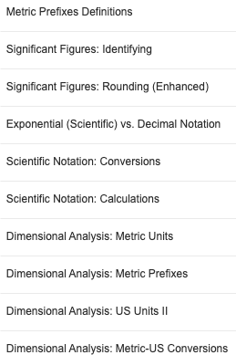

# **Chapter 3**

## *Atomic Structure and the Periodic Table*

[Cengage Chapter 3 link on Canvas](https://bridgeport.instructure.com/courses/2177365/modules/items/46775385)

[Lecture ppt slide Link](https://drive.google.com/file/d/1OH0ww4TZdVJIvW-nHc409fvs65NVoTOA/view?usp=sharing)

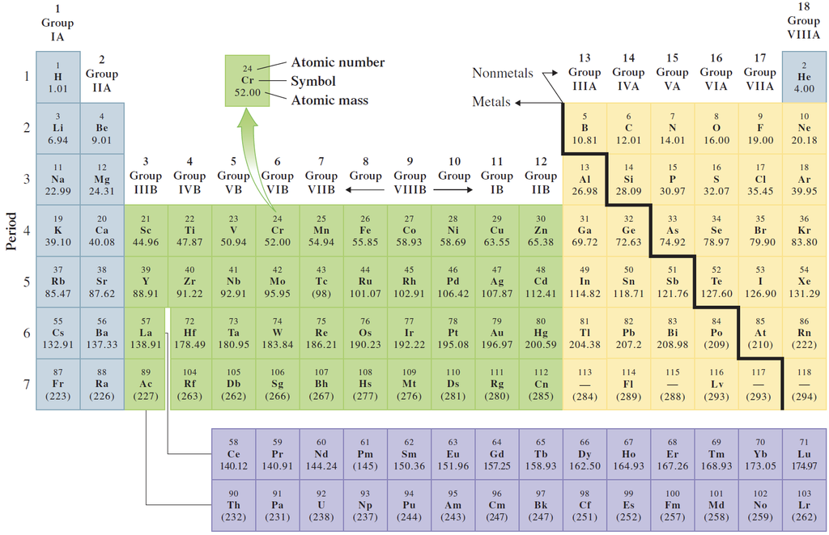

- **Atomic Structure**. Understand how an atom is composed of subatomic particles (protons, neutrons and electrons) and the properties and locations of the sub-atomic particles within the atom. Know how to draw correct complete chemical symbol for an atom containing protons, neutrons.
- **Isotopes**. Know what an isotope is. If given an isotopic symbol (F-19) be able to find the correct number of protons, neutrons and electrons (9p+, 10n, 9e-).
- **Periodic Law and Table**. What is the periodic law and how is it related to the periodic table? On the periodic table, be able to identify: a) groups and periods; b) an element if given its group and period c) the alkali, alkaline earth, halogen and noble gas groups; d) metals and nonmetals; and e) the representative (main group) elements, transition metal elements and inner transition metal elements.
- **Electronic Structure of Atoms**. Understand how electrons in atoms are organized into electron shells, subshells and orbitals and how each of these levels of organization is defined. Be able determine how many subshells exist within a given shell and be familiar with the letter designations for subshells (s, p, d, and f). What do all orbitals of a given subshell have in common? How many electrons can fit in one orbital?
- **Electron Configurations**. Understand how electrons are configured within an atom using orbital diagrams. Know the subshell filling order of the periodic table and how many electrons can fit into each subshell type. Be able to generate the correct electron configuration for any element using either an orbital diagram or the shorthand notation (e.g. for C, 1s<sup>2</sup>2s<sup>2</sup>2p<sup>2</sup>). Understand how electron configurations explain the periodic law.

## **Concept Check and/or Class Practice**

- The subatomic particles of an atom are: (a) protons and neutrons. (b) protons and electrons. (c) neutrons and electrons. (d) protons, neutrons, and electrons.
- What is the correct complete chemical symbol for an atom containing 25 protons and 30 neutrons?

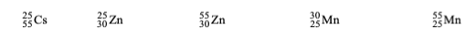

- The atomic number of an atom is: (a) the sum of the number of protons in the nucleus of an atom. (b) the number of neutrons in the nucleus of an atom. (c) obtained from the mass number. (d) the number of protons and the number of electrons in an atom.
- Atoms of an element that contain a different number of neutrons are known as: (a) nucleophiles. (b) isotopes. (c) isophiles. (d) neutrophiles.
- which of the following element is isotopes?

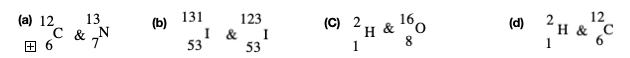

- Elements are arranged in the periodic table according to: (a) increasing number of neutrons. (b) increasing number of neutrons and protons. (c) increasing atomic number. (d) increasing atomic mass unit.
- An atom contains 33 protons, 35 neutrons and 33 electrons. The atomic number and mass number for this atom are, respectively, (a) 35 and 33 (b) 33 and 35 (c) 33 and 66 (d) 33 and 68 (e) 35 and 68
- Differences between metals and nonmetals are: (a) metals conduct electricity while nonmetals do not. (b) metals are generally solids while nonmetals exist as gases, liquid, or solids. (c) metals are malleable while nonmetals are brittle in the solid state. (d) all of these.
- The space in which electrons move rapidly about a nucleus is divided into: (a) shells and subshells. (b) shells, subshells, and orbitals. (c) shells and orbitals. (d) subshells and orbitals.
- The electron configuration of sodium is  
  (a) 1s<sup>2</sup>1s<sup>2</sup>2p<sup>6</sup>3s<sup>1</sup> (b) 1s<sup>2</sup>2s<sup>2</sup>2p<sup>6</sup>3s<sup>1</sup> (c) 1s<sup>2</sup>2s<sup>2</sup>2p<sup>7</sup> (d) 1s<sup>2</sup>2s<sup>1</sup>2p<sup>6</sup>3s<sup>1</sup>
- Elements within vertical columns in the periodic table share similar chemistry. These columns are called: (a) shells (b) subshells (c) orbitals (d) periods (e) groups
- Columns in the periodic table are known as groups. Elements in groups have similar chemical properties because they contain the same number of: (a) total electrons. (b) protons. (c) outer shell valence electrons. (d) neutrons.
- Consider two elements: One is a gas and the other is a solid. Each contain identical number of electrons in their outer shell. These elements are _____ and _____. They contain _____ and _____ neutrons, respectively. (a) F; I; 10; 74 (b) N; S; 14; 32 (c) O; S; 16; 32 (d) F; I; 19; 127
- You are asked to determine the composition of a gas. There are three components with three different applications. They all have the same atomic number, but the number of neutrons is zero, one, and two, respectively. One of the components is used as a radioactive tracer in biological experimentation. Identify the gas you were given. How are the three components referred? What are the names of each component? (a) Carbon; isotopes; carbon-12; carbon-13; and carbon-14 (b) Hydrogen; isotopes; protium; deuterium; and tritium (c) Hydrogen; elements; protium; deuterium; and tritium (d) Oxygen; elements; oxygen-8; oxygen-15; and oxygen-16
- How many electrons and protons are in Na<sup>+</sup> ion (cation) contain, Na is which group element in the periodic table and how many valence electrons(s) are in Na?

### [**Cengage Chapter 3 electronic online h.w. on Canvas topics:**](https://bridgeport.instructure.com/courses/2177365/modules/items/46775410)

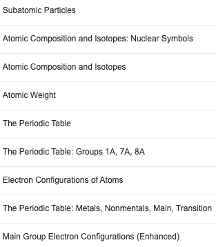

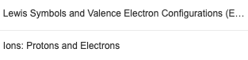

# **Chapter 4**

### *Chemical Bonding: The Ionic Bond Model*

[Cengage Chapter 4 Link on Canvas](https://bridgeport.instructure.com/courses/2177365/modules/items/46775387)

[Lecture ppt slides link](https://drive.google.com/file/d/1HG20EMTUqeFE5VLziu86dE392W0-nJJs/view?usp=sharing)

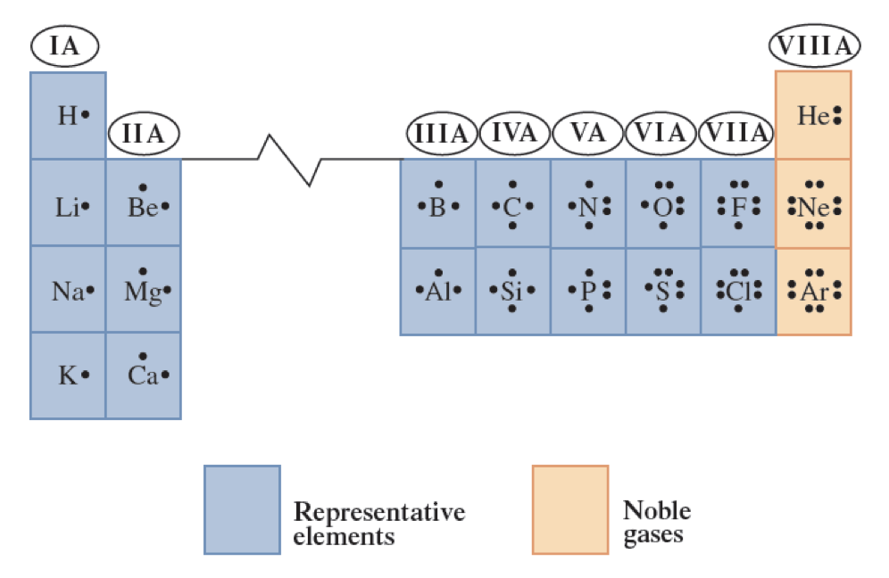

- **Chemical bonding**. What is a chemical bond? Understand the difference between an ionic bond (electron transfer) and a covalent bond (shared electrons)
- **Ionic versus covalent compounds**. What simple experimental test can be used to determine if a compound is ionic or covalent (i.e. lecture demonstration)? Be able to determine if a compound is ionic or covalent from its molecular structure.
- **Ions**. Understand how atoms can gain or lose electrons to form anions (negatively charged ions) or cations (positively charged ions). Be able to quickly interconvert between the number of protons and electrons in an ion and the ionic symbol (e.g., O2 8P, 10E).
- **Molecular Compound Lewis Structures**. Be able to draw the Lewis structure of a molecular compound. Understand how many bonds each element typically forms and how to form double and triple bonds.
- **Octet Rule, periodic trends in ion charges and valence electrons**. Understand what the octet rule is. Know which elements tend to form cations, which elements tend to form anions, and the periodic patterns for the charges of the cations and anions of representative elements. (Lecture)
- **Ionic Compound Formula Unit**. Understand that ionic compounds exist in an extended array of alternating cations and anions and no separate “molecules” of ionic compounds exist. What does the formula unit of an ionic compound represent?
- **Simple Ionic Compound Naming**. Be able to interconvert between formula name for simple binary ionic compounds. Understand how to name binary ionic compounds containing cations with a fixed charge and cations with a variable ionic charge.
- **Physical properties of ionic compounds**. Understand melting points, boiling points and aqueous solution of ionic compounds. (Lecture)
- **Polyatomic Ion Compound Naming**. Know how to name polyatomic ions and compounds containing poly atomic ions. Memorize the formulas/charges/names of the polyatomic ions: nitrate, nitrite, ammonium, sulfate, hydrogen sulfate, sulfite, hydrogen sulfite, phosphate, hydrogen phosphate, dihydrogen phosphate, phosphate, carbonate, hydrogen carbonate, acetate, hydronium, and hydroxide.

## **Concept Check and/or Class Practice**

- Which of the following elements would be expected to form a cation with a +2 charge?  
  (a) Na (b) Mg (c) Al (d) S (e) Cl
- What would be the correct symbol for an element with 19 protons, 20 neutrons and 18 electrons? (a) K<sup>+</sup> (b) Ca<sup>2+</sup> (c) Ar (d) K<sup>-</sup> (e) K<sup>2-</sup>
- An ionic bond is formed by the: (a) sharing of one or more electrons between atoms. (b) sharing of two or more electrons between atoms. (c) transfer of one or more electrons from one atom to another. (d) transfer of two or more electrons from one atom to another.
- A valence electron is an electron in the outer-most electron shell of an atom. The shorthand method developed by scientists to represent the number of valence electrons in an atom involves the use of: (a) ionic bond model. (b) dot symbols. (c) octet rule. (d) Lewis symbols or electron-dot symbols.
- What is the electron configuration of the magnesium ion? (a) 1s<sup>3</sup>2s<sup>2</sup>2p<sup>6</sup> (b) 1s<sup>2</sup>2s<sup>2</sup>2p<sup>6</sup>3s<sup>2</sup> (c) 1s<sup>2</sup>2s<sup>2</sup>2p<sup>6</sup>3s<sup>1</sup> (d) 1s<sup>2</sup>2s<sup>2</sup>P<sup>6</sup>
- In which of the following pairs of compounds are both members of the pair ionic compounds? (a) PI<sub>3</sub> and HBr (b) H<sub>2</sub>S and NCl<sub>3</sub> (c) LiF and H<sub>2</sub>O (d) LiI and NiO
- Which of the following has highest boiling point: (a) sea water (b) drinking water (c) Sweet water d)lime water
- The rule that states that atoms lose, gain, or share electrons to form a noble-gas electron configuration is known as the: (a) octet rule. (b) electron rule. (c) noble gas rule. (d) bonding rule.
- How many electrons make up a covalent bond?
- Draw the correct Lewis dot electron symbols for the following compound. (a) H<sub>2</sub>O (b) NH<sub>3</sub> (c) CO<sub>2</sub>
- which of the following molecule(s) is polar? (a)Hexane, C<sub>6</sub>H<sub>14</sub> (b) Water, H<sub>2</sub>O (c) Methane gas, CH<sub>4</sub> (d) Hydrogen sulfide, H<sub>2</sub>S (e) Carbon dioxide, CO<sub>2</sub>O (f) both b and d
- Determine the chemical formula for the compound that is formed when each of the following pairs of ions interact. (a) Ba<sup>2+</sup> and Cl<sup>-</sup> (b) Fe<sup>3+</sup> and O<sup>2-</sup> (c) Pb<sup>4+</sup> and O<sup>2-</sup> (d) Al<sup>3+</sup> and Cl<sup>-</sup>
- What term is used to refer to the smallest whole-number repeating ratio of ions present in an ionic compound? (a) Molecule unit (b) Ion unit (c) Ion molecule unit (d) Formula unit
- Name each of the following compounds: (a) K<sub>2</sub>S (b) Fe<sub>2</sub>O<sub>3</sub> (c) CoCl<sub>2</sub>
- What is a polyatomic ion? (a) An ion formed by a group of positive and negative ions. (b) An ion formed from a group of atoms held together by covalent bonds and is positively or negatively charged. (c) An ion formed by a group of positive and negative ions held together by covalent bonds. (d) All of these.
- What is the correct chemical formula for the combination of ammonium(NH<sup>4+</sup>) and carbonate (CO<sub>3</sub><sup>2-</sup>) ions? (a) 2(NH<sub>4</sub>)CO<sub>3</sub> (b) 2NH<sub>4</sub>CO<sub>3</sub> (c) (NH<sub>4</sub>)<sub>2</sub>CO<sub>3</sub> (d) NH<sub>4</sub>CO<sub>3</sub>
- After placing a soft, lustrous, and malleable material in a container of yellowish gas, a violent reaction occurs leaving a white crystalline material. You decide to break the rule “Never taste chemicals in a laboratory” and find that it tastes very salty. Which of the following is correct?

a) Not enough information is provided to determine what the two materials and product are.  
b) The two materials are likely to be the elements sodium and chlorine reacting to share electrons to produce the molecular compound sodium chloride.  
c) The two materials are likely to be the elements sodium and chlorine, both reacting by a transfer of electrons to produce the ionic compound sodium chloride.  
d) The two materials are homogenous compounds reacting to produce an unidentifiable salt.

Fill in the following table with the correct information.

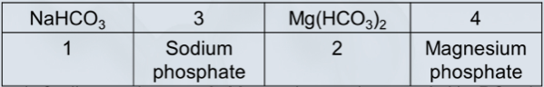

1 Sodium carbonate; 2. Magnesium carbonate; 3. Na<sub>3</sub>PO4; 4. MgPO<sub>4</sub>  
1 Sodium hydrogen carbonate; 2. Magnesium bicarbonate; 3. Na<sub>3</sub>PO<sub>4</sub>; 4. Mg<sub>3</sub>(PO<sub>4</sub>)<sub>2</sub>  
1 Sodium hydrogen carbonate; 2. Magnesium bicarbonate; 3. Na(PO<sub>4</sub>)<sub>3</sub>; 4. Mg<sub>3</sub>PO<sub>4</sub>  
1 Sodium hydrogen carbonate; 2. Magnesium bicarbonate; 3. NaPO<sub>4</sub>; 4. Mg<sub>3</sub>(PO<sub>4</sub>)<sub>2</sub>

### [**Cengage Chapter 4 (or 5) electronic online h.w. on Canvas topics**:](https://bridgeport.instructure.com/courses/2177365/modules/items/46775411)

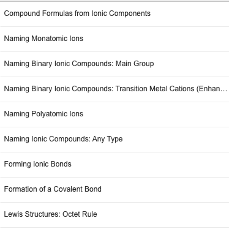

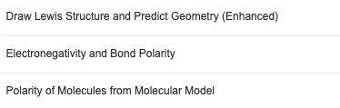

# **Chapter 05**

## *Chemical Bonding: The Covalent Bond Model*

[Cengage Chapter 5 Link on Canvas](https://bridgeport.instructure.com/courses/2177365/modules/items/46775389)

[Lecture ppt slides link](https://drive.google.com/file/d/1g0VnLzN0Rqz-31vjxJFPJRsO3hyA5T2l/view?usp=sharing)

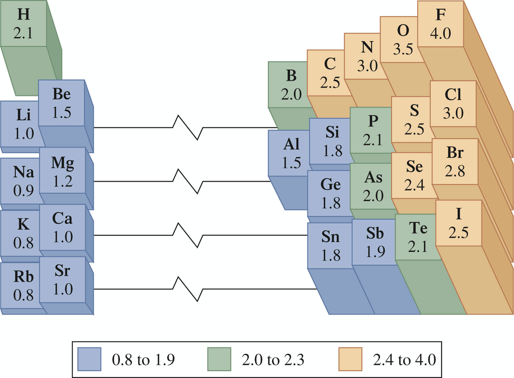

- **Covalent Bond**. Understand what a covalent bond is and how it differs from an ionic bond. Know how to use both the electron dot and dash notations to represent a covalent bond.
- **Molecular Compound Lewis Structures**. Be able to draw the Lewis structure of a molecular compound. Understand how many bonds each element typically forms and how to form double and triple bonds.
- **Systematic Process for Drawing Lewis Structures**. Using the systematic process described in the text and lecture to draw the Lewis structure of any molecular compound. Understand the principles presented in lecture in which electonegativity and bond polarity can be used to determine the correct “skeleton” structure.
- **Electronegativity and Bond Polarity**. Understand what electronegativity is and the periodic trends in electronegativity in the representative elements of the periodic table. Understand how to represent the unsymmetrical distribution of electrons in a polar bond. Be able to sort a series of bonds in order of increasing polarity.
- **Molecular Geometry**. Understand the VSEPR principles used to predict molecular geometry. Be able to VSEPR principles to predict the electron group arrangement and molecular geometry of a molecular compound. (Lecture)
- **Molecular Polarity**. Based upon the presence of polar bonds and the molecular geometry, be able to determine if a molecule is polar (unsymmetrical distribution of e- charge) or nonpolar (symmetrical distribution of e- charge).

## **Concept Check and/or Class Practice**

- A covalent bond occurs when: (a) there is a transfer of electrons only between similar or identical atoms. (b) there is a transfer of electrons only between similar atoms. (c) there is a sharing of valence electrons between similar or identical atoms. (d) there is a sharing of electrons between a metal and nonmetal.
- What is the difference between bonding electrons and lone electron pairs? (a) Bonding electrons are valence electrons that are shared between atoms and lone electron pairs are nonbonding electrons. (b) Bonding electrons are shared between two identical atoms and lone electron pairs are shared between two nonidentical atoms. (c) Bonding electrons and lone electron pairs are interchangeable terms used to identify electrons in a covalent bond. (d) Bonding electrons are involved in the formation of covalent bonds and lone electron pairs are involved in formation of ionic bonds.
- How many electrons are shared in a double covalent bond? (a) 2 (b) 4 (c) 6 (d) 8
- How many covalent bonds can oxygen form? (a) 1 (b) 2 (c) 4 (d) 8
- Draw a Lewis structure for each of the following molecules (a) H<sub>2</sub> (b) F<sub>2</sub> (c) HF (d) NH<sub>3</sub> (e) CO<sub>2</sub> (f) CCl<sub>4</sub>
- Determine the shape for each of the following molecules, and mention their bond angles (a) HCN (b) NH<sub>3</sub>  
  (c) O<sub>3</sub>
- Which of the following elements has the highest electronegativity? (a) H (b) He (c) O (d) Cl
- Arrange the following bonds in the descending order of polarity (a) N–F O–F C–F (b) C–F N–O Si–F (c) Cl–Cl B–Cl S–Cl
- Which of the following bonds would be the least polar/most polar yet still be considered polar covalent/without being considered ionic? (a) Mg–O (b) C–O (c) O–O (d) Si–O (e) N–O
- Which statement best describes a polar covalent bond? (a) In a polar covalent bond, there is equal sharing of electrons between two atoms. (b) In a polar covalent bond, there is unequal sharing of electrons between two atoms. (c) In a polar covalent bond, there is equal sharing of electrons between identical atoms. (d)In a polar covalent bond, there is unequal sharing of electrons between identical atoms.
- Which of the following molecules are polar? (a) F<sub>2</sub> (b) HF (c) NH<sub>3</sub> (d) SO<sub>2</sub> (e) CCl<sub>4</sub> (f) CO<sub>2</sub> (g) BeCl<sub>2</sub> (h) H<sub>2</sub>O (i) CH<sub>4</sub>
- Which of the following compounds is named incorrectly? (a) NO<sub>2</sub> nitrogen dioxide (b) P<sub>2</sub>O<sub>5</sub> phosphorus pentoxide (c) PCl<sub>3</sub> phosphorus trichloride (d) SO<sub>3</sub> sulfur trioxide (e) ICl iodine monochloride
- A liquid molecular compound is given to you and you are told to handle it with caution. It can cause damage or death if it is consumed in large quantities, if it enters your lungs, if you are hit with a frozen chunk of this material, or if a hot solution of it is spilled on you; however, this liquid is necessary to sustain life. The liquid is a pure molecular compound, has no taste, and is known to contain hydrogen and oxygen. Identify the liquid, its molecular geometry, and whether it is polar or nonpolar. (a) Water; linear; polar (b) Water; linear; nonpolar (c) Water; angular; nonpolar (d) Water; angular; polar

# **Chapter 06**

## *Chemical Calculations: Formula Masses, Moles, and Chemical Equations*

[Cengage Chapter 6 Link on Canvas](https://bridgeport.instructure.com/courses/2177365/modules/items/46775391)

[Lecture ppt slides link](https://drive.google.com/file/d/1VwQR6ek1c0zIDzm8tZxj5-fv20tzbDhH/view?usp=sharing)

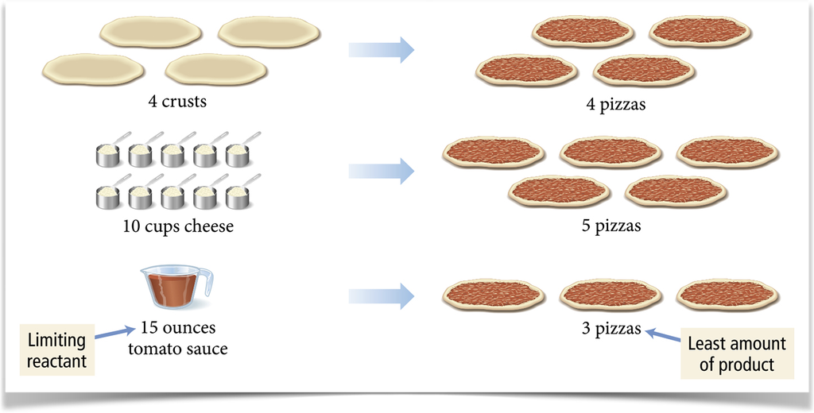

## **Concept Check and/or Class Practice**

- What is the formula mass/molar mass of H<sub>2</sub>SO<sub>4</sub>? (a) 49 amu (b) 50 amu (c) 146 amu (d) 98 amu
- Calculate the mass, in grams, of a 2.5 mole sample of ethane, C<sub>2</sub>H<sub>6</sub>.
- Calculate the number of moles in 50.0 g of H<sub>2</sub>O.
- Aspirin has a molecular formula of C<sub>9</sub>H<sub>8</sub>O<sub>4</sub>. What is the mass of 1 mole of aspirin? (a) 325 mg (b) 85 mg (c) 180 g (d) 200 mg
- How many moles are contained in 0.500 g of fructose (fructose formula C<sub>6</sub>H<sub>12</sub>O<sub>6</sub> )
- How many moles of carbon atoms and hydrogen atoms are present in a 2.5 mole sample of ethane, C<sub>2</sub>H<sub>6</sub>?
- In the molecular formula of aspirin, C<sub>9</sub>H<sub>8</sub>O<sub>4</sub>, how many moles of carbon atoms, hydrogen atoms, and oxygen atoms are present? (a) 9; 8; 4 (b) 2.72 x 10<sup>24</sup>; 4.82 x 10<sup>24</sup>; 2.41 x 10<sup>24</sup> (c) 6.02 x 10<sup>23</sup> of each (d) 1; 1; 1
- 50 g of MgCl2 contains (a) 0.52 mol (b) 0.84 mol (c) 1.2 mol (d) 1.9 mol
- How many atoms are present in 10.4 g Ge? (a) 0.143 (b) 8.62×1022 (c) 6.26×1024 (d) 4.55×1026 (e) None of these
- Calculate the number of copper atoms in a 63.55 g sample of copper
- Which of the following 100.0 g samples contains the greatest number of atoms? (a) Magnesium (b) Zinc (c) Silver
- The formula of aspirin is C<sub>9</sub>H<sub>8</sub>O<sub>4</sub>. Calculate the number of molecules in a 0.325 g tablet of aspirin.

(a) 1.81 x 10<sup>-3</sup> (b) 1.09 x 10<sup>21</sup> (c) 6.02 x 10<sup>23</sup> (d) 1.09 x 10<sup>-23</sup>

- Which of the following correctly balances the chemical equation given below?

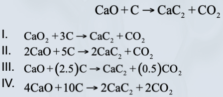

- What is the correct balanced chemical equation for the process of heating sodium bicarbonate to produce sodium carbonate, carbon dioxide, and water?

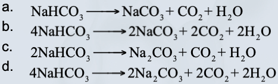

- In the equation,C<sub>2</sub>H<sub>6</sub> + O<sub>2</sub> ----> CO<sub>2</sub> + H<sub>2</sub>O what are the correct coefficients in the balanced equation, and what is the correct mole-to-mole relationship? (a) 1, 3.5, 2, 3 ; 1 mole of C<sub>2</sub>H<sub>6</sub> produces 3 moles of H<sub>2</sub>O (b) 4, 14, 8, 6 ; 4 moles of C<sub>2</sub>H<sub>6</sub> produce 6 moles of H<sub>2</sub>O (c) 1, 2, 3, 3 ; 1 mole of C<sub>2</sub>H<sub>6</sub> produces 3 moles of H<sub>2</sub>O (d) 2, 7, 4, 6, ; 2 moles of C<sub>2</sub>H<sub>6</sub> produce 6 moles of H<sub>2</sub>O
- A 2 L bottle of carbonated soda has, on an average, 0.20 g of glucose per 100 mL. Glucose is metabolized in the human body according to the equation C<sub>6</sub>H<sub>12</sub>O<sub>6</sub> + O<sub>2</sub> ----> CO<sub>2</sub> + H<sub>2</sub>O Which of the following equations would be used to determine the number of grams of CO<sub>2</sub> produced after the consumption of ten 2 L bottles of carbonated soda?

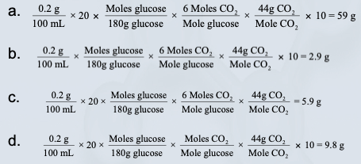

- Balance following equation: CH<sub>4</sub>(g) + Cl<sub>2</sub>(g) ----> CCl<sub>4</sub>(g) + HCl(g)
- How many moles and grams of H<sub>2</sub>O are formed from 4.8 moles of H<sub>2</sub>? Use the balanced equation for the reaction of H<sub>2</sub> and O<sub>2</sub> to form H<sub>2</sub>O.

2H<sub>2</sub> + O<sub>2</sub> ----> 2H<sub>2</sub>O

### [**Cengage Chapter 6 electronic online h.w. on Canvas topics**:](https://bridgeport.instructure.com/courses/2177365/modules/items/46775412)

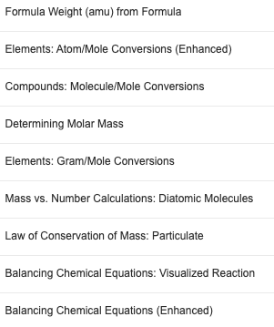

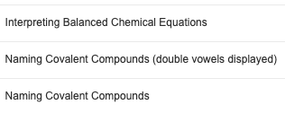

# **Chapter 07**

## *Gases, Liquids, and Solids*

[Cengage Chapter 7 Link on Canvas](https://bridgeport.instructure.com/courses/2177365/modules/items/46775393)

[Lecture ppt slides link](https://drive.google.com/file/d/12ChiYr9lAT5V7wvolwJxmabJRFRzxNMB/view?usp=sharing)

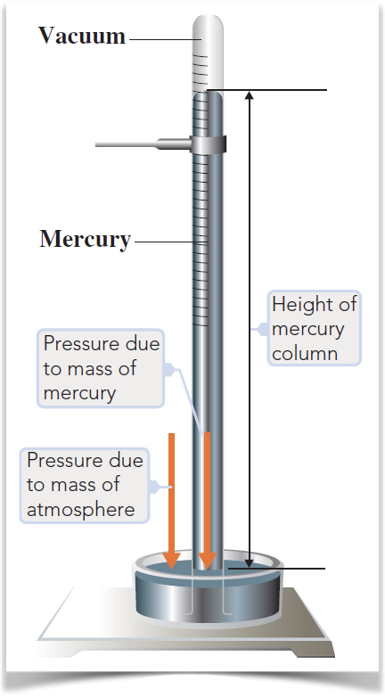

- **Pressure & Temperature**. Be able to interconvert between different units of pressure. You should memorize the conversion factor 760 torr (mm Hg) = 1 atm.
- **Ideal Gas Law Calculations I (Two state problems)**. When one or more variables of a gas is Troed, be able to use the ideal gas law to calculate the effect on the unknown variable. You can use this strategy to solve all the problems involving the simple gas laws (Boyle’s, Charles’, Gay-Lussac’s and Avogadro’s law). .
- **Ideal Gas Law**. Understand how the four simple gas laws (Boyle’s, Charles’, Gay-Lussac’s and Avogadro’s) can be incorporated into a common law known as the ideal gas law. Memorize the ideal gas law, PV = nRT.
- **Ideal Gas Law Calculations II**. If given any three of P, V, n or T, know how to use the ideal gas law to solve for the fourth.
- **Partial Pressures Gas Law**. Know how to use Dalton’s law in any of its various versions to find the partial pressures of each gas in a mixture of gases.
- **Intermolecular Forces**. Understand the three different types of intermolecular forces: London forces, dipole-dipole forces, and hydrogen bonding. Be able to rank them in order of increasing strength of the interaction. From the Lewis structure of a molecule, be able to predict which types of intermolecular forces it can participate in. Based upon intermolecular attractions, be able to predict which substance will have the highest boiling point.

## **Concept Check and/or Class Practice**

- What are the three physical states of matter? (a) Gases, liquids, and matter characterized by potential and kinetic energy (b) Solids, liquids, and matter characterized by a dominance of potential energy (c) Liquids, solids, and matter characterized by potential and kinetic energy (d) Gases, liquids, and solids
- What are the four variable involved in gas laws? (a) Pressure, volume, temperature, and molar amount (b) Pressure, volume, temperature, and force applied per unit area of an object (c) Volume, temperature, molar amount, and heat (d) Temperature, molar amount, pressure, and compression
- Why are gases so much easier to compress into smaller volumes compared to solids and liquids?
- Which of the following is the correct mathematical equation for Boyle’s law?

> $$ \frac {P1}{V1} = \frac {P2}{V2} $$ $$ \frac {P1}{T1} = \frac {V2}{T2} $$ $$ P1V1 = P2V2 $$ $$ \frac {P1}{T1} = \frac {P2}{T2} $$
- A sample of helium gas occupies 12.4 L at 23°C and 0.956 atm. What volume will it occupy at 1.20 atm assuming that the temperature stays constant?
- Which law states that the volume of a fixed amount of gas is directly proportional to its Kelvin temperature at constant pressure? (a) Boyle’s law (b) Charles’s law (c) Kelvin’s law (d) Gay-Lussac’s law
- Suppose a balloon containing 1.30 L of air at 24.7°C is placed into a beaker containing liquid nitrogen at –78.5°C. What will the volume of the sample of air become (at constant pressure)?
- What is the mathematical equation for the combined gas law?

> $$ P1V1T1 = P2V2T2 $$ $$ \frac{P1T1}{V1} = \frac{P2T2}{V2} $$ $$ \frac{V1T1}{P1} = \frac{V2T2}{P2} $$ $$ \frac{P1V1}{T1} = \frac{P2V2}{T2} $$
- At what temperature (in °C) does 121 mL of CO<sub>2</sub> at 27°C and 1.05 atm occupy a volume of 293 mL at a pressure of 1.40 atm?
- The ideal gas law describes the relationship between the variables: (a) temperature and pressure. (b) temperature, pressure, and volume. (c) temperature, pressure, volume, and molar amount. (d) pressure, volume, and molar amount.
- An automobile tire at 23°C with an internal volume of 25.0 L is filled with air to a total pressure of 2.18 atm (32 pounds per square inch). Determine the number of moles of air in the tire.
- what will happen to the volume a fixed mass of gas if the pressure and kelvin temperature are doubled? (a) increases by a factor of 4 (b) increases by a factor of 2 (c) remains the same (d) decreases by a factor of 2 (e) decreases by a factor of 4
- What is the pressure in a 304.0 L tank that contains 5.670 kg of helium at 25°C?
- Which do gas laws describe more accurately: a gas at high pressure and low temperature or a gas at low pressure and high temperature?
- How many moles and molecules are contained in 1.5 L of CO<sub>2</sub> at STP?
- What is the volume of 5.00 mol of He at 273 ºC and 1,520 torr?
- A gas mixture consisting of oxygen, helium, and nitrogen has a total pressure of 780 mm Hg. What is the partial pressure of oxygen if the partial pressures of helium and nitrogen are 86 mm Hg and 124 mm Hg, respectively? (a) 694 mm Hg (b) 656 mm Hg (c) 990 mm Hg (d) 570 mm Hg
- What is the difference between an endothermic and an exothermic change of state? (a) Heat energy is given off in an endothermic change of state and absorbed in an exothermic change of state. (b) Heat energy is absorbed in an endothermic change of state and is given off in an exothermic change of state. (c) Direct change from gaseous state to solid state occurs in an endothermic reaction and direct change from solid to gaseous state (d) occurs in an exothermic reaction. (e) Both (b) and (c).
- In Denver water boils at 95.0 °C, rather than at 100.0 °C as at sea level in Hawaii because: (a) Denver has a cooler climate (b) the atmospheric pressure is higher (c) the atmospheric pressure is lower (d) water has more vapor pressure at high altitudes (e) water has less vapor pressure at high altitudes
- Identify whether heat is absorbed or released during the evaporation of a liquid. (a) Heat is released. (b) Heat is absorbed. (c) Heat is both released and absorbed. (d) Heat is neither released nor absorbed because all molecules of a liquid possess the same kinetic energy.
- A liquid in a closed container evaporates for a short time and then condenses as the number of vapor molecules increase. This process is known as. (a) physical equilibrium (b) volatility (c) vapor pressure (d) condensation
- The boiling point of a liquid is defined as: (a) the temperature at which the vapor pressure of a liquid is less than the atmospheric pressure exerted on the liquid. (b) the temperature at which the vapor pressure of a liquid is more than the atmospheric pressure exerted on the liquid. (c) the temperature at which the vapor pressure of a liquid is equal to the atmospheric pressure exerted on the liquid. (d) the temperature at which a liquid boils at a pressure greater than 760 mm Hg.
- With respect to intermolecular forces in a liquid, which one is the strongest? (a) Dipole–dipole interaction (b) Hydrogen bonding (c) London forces (d) No correct response
- Which has the stronger intermolecular forces? explain. (a) N<sub>2</sub> (b) H<sub>2</sub>O
- Place the following substances in order of decreasing boiling point. (a) H<sub>2</sub>O, Cl<sub>2</sub>, CO. (b) C<sub>2</sub>H<sub>6</sub>, CH<sub>3</sub>OH, CH<sub>3</sub>Br. (c) F<sub>2</sub>, Cl<sub>2</sub>, I<sub>2</sub>.
- To hide some helium filled balloons for a birthday party, you decide to place them in a chest freezer. When you retrieve them, you are disappointed to find the balloons deflated. As they warm up to room temperature, they return to their original size. What gas law is demonstrated, in this scenario? What happens to the kinetic energy of the helium during the warming process? (a) Boyle’s law; the kinetic energy decreases (b) Boyle’s law; the kinetic energy increases (c) Charles’s law; the kinetic energy decreases (d )Charles’s law; the kinetic energy increases

### [**Cengage Chapter 7 electronic online h.w. on Canvas topics**:](https://bridgeport.instructure.com/courses/2177365/assignments/21600995) *includes couple question Lesson 06 Chemical reaction, and* [Gas Calculation and Intermolecular forces](https://bridgeport.instructure.com/courses/2177365/assignments/21601002)

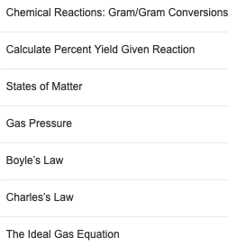

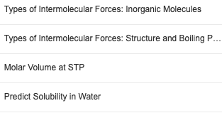

# **Chapter 08**

## *Solutions*

[Cengage Chapter 8 Link on Canvas](https://bridgeport.instructure.com/courses/2177365/modules/items/46775395)

[Lecture ppt slides link](https://drive.google.com/file/d/1sEdlgMZmOkDSCkncRNX1C7eYoeDDhq6S/view?usp=sharing)

[figure not shown]

- **Solutions Terminology**. Understand the meaning of the following terms well enough to be able to provide a definition of them: solute, solvent, solution, solubility, saturated solution, unsaturated solution, supersaturated solution, concentrated solution, dilute solution, aqueous solution, nonaqueous solution.
- **Effect of Temperature and Pressure on Solubility**. Know the effect that temperature has on the solubility of gas solutes and solid solutes in water. Know Henry’s Law – the effect that pressure has on the solubility of gaseous solutes.
- **Solution Formation**. Be able to explain how solution formation occurs in terms of the interparticle attractions between solute and solvent particles. Know the two factors that influence the rate of solution formation.
- **Solubility Rules**. Memorize the general “like dissolves like” and/or “polar dissolve to polar (solvent) nonpolar dissolve to nonpolar (solvent)” solubility rule. know how to apply it, and know which types of solutes for which it is applicable. Be able to use the solubility guidelines for ionic compounds given in Lecture (or similar solubility “rules”) to predict whether an ionic compound will be soluble or insoluble in water.
- **Solution Concentration Units**. Understand how to calculate percent concentration as %(m/m), %(v/v) and %(m/v). Also know how to calculate concentration in units of molarity. Be able to perform calculations in which concentration is used as a conversion factor.
- **Colligative Properties of Solutions**: Be able to understand the effect of dissolved solutes on the physical properties of solution (vapor pressure, freezing point, boiling point, osmotic pressure).

## **Concept Check and/or Class Practice**

- A homogenous mixture containing 80 mL of water and 20 mL of alcohol, identify the solvent and the solute. (a) Water is the solute, and alcohol is the solvent. (b) Water is the solvent, and alcohol is the solute. (c) Neither, since it is a homogenous mixture. (d) Both, since one is dissolving the other.
- What is the solvent in the gaseous solution we call air?
- How does the temperature and pressure affect the solubility of a gas in water? (a) Increased temperature decreases gas solubility, and increased pressure increases gas solubility. (b) Increased temperature increases gas solubility, and increased pressure increases gas solubility. (c) Increased temperature decreases gas solubility, and increased pressure decreases gas solubility. (d) Decreased temperature decreases gas solubility, and decreased pressure increases gas solubility.
- Greater difference in solute–solvent polarity results in: (a) greater solubility of the solute. (b) less solubility of the solute. (c) no effect on the solubility of the solute. (d) an increase in the solvent’s ability to dissolve the solute.
- What is the percent by mass concentration of glucose in a solution made by dissolving 5.5 g of glucose in 78.2 g of water?
- Calculate the volume percent of solute in 30.0 mL of methyl alcohol in enough water to give 435 mL of solution.
- A solution having a mass percent concentration of 10% contains: (a) 10 g of solute and 90 g of solvent. (b) 10 g of solvent and 10 g of solute. (c) 10 g of solute per 100 g of solvent. (d) 10 g of solvent per 100 g of solute.
- which of the following compound is not water soluble? (a) ethanol, C<sub>2</sub>H<sub>5</sub>OH (b) sodium chloride, NaCl (c) cyclohexane, C<sub>6</sub>H<sub>12</sub> (d) acetic acid, CH<sub>3</sub>COOH (e) none of these
- which of the following has the highest melting point? (a) NaCl (b) Glucose (c) C<sub>2</sub>H<sub>6</sub> (d) NH<sub>3</sub> (e) CH<sub>3</sub>OH
- What is the definition of molarity? (a) Moles of solute per mole of solution (b) Moles of solute per liter of solution (c) Liters of solute per mole of solution (d) Liters of solute per liter of solution
- You have 1.00 mol of sugar in 125.0 mL of solution. Calculate the concentration in units of molarity.
- What is the molarity of a solution containing 5 g of NaOH in 2.00 L of solution?
- How would you prepare 100 mL of 0.9% saline solution in water from a 10% saline solution? (a) 90 mL of 10% saline solution + 100 mL of water (b) 90 mL of 10% saline solution + 10 mL of water (c) 9 mL of 10% saline solution + 100 mL of water (d) 9 mL of 10% saline solution + 91 mL of water
- A 0.50 M solution of sodium chloride sits on a lab bench. Which of the following would decrease the concentration of the salt solution? (a) Add water to the solution. (b) Pour some of the solution down the sink drain. (c) Add more sodium chloride to the solution. (d) Let the solution sit out in the open air for a couple of days. (e) At least two of the above would decrease the concentration of the salt solution.
- What is the minimum volume of a 2.00 M NaOH solution needed to make 150.0 mL of a 0.800 M NaOH solution?
- How many milliliters of a 4.0 M solution must be used to prepare 250 mL of a 0.080 M solution?
- How does the addition of a nonvolatile solute to a solvent affect the vapor pressure of the resulting solution? (a) Decreases the vapor pressure (b) Increases the vapor pressure (c) Has no affect on the vapor pressure (d) No correct response
- Differentiate moles and molarity.
- Write two method to increase the solubility of solute in solvent.
- A cell that is in an isotonic environment? (a) when the amount of water in cell is higher than the amount of solute in a cell (b) movement of water across a semi permeable membrane (c) a cell that has an equilibrium of water to solute (d) when the amount of water and solute in a cell are at equilibrium (e) none of these
- How would you prepare 200 mL of a 0.8 M sodium hydroxide, molar mass = 40 g/mole, solution in water? Identify the solute and solvent. (a) Add 64 g of sodium hydroxide to 200 mL of water. The solvent is water, and the solute is sodium hydroxide. (b) Add 64 g of sodium hydroxide to 200 mL of water. The solvent is sodium hydroxide, and the solute is water. (c) Add 6.4 g of sodium hydroxide to 200 mL of water. The solvent is water, and the solute is sodium hydroxide. (d) Add 6.4 g of sodium hydroxide to 200 mL of water. The solvent is sodium hydroxide, and the solute is water.
- If you add 2.6 g of sodium chloride, molar mass = 58 g/mole, to 300 mL water, what is the molarity, percent (m/v), and osmolarity of this solution? (a) 0.15 M, 0.9%, and 0.30 osmol (b) 0.15 M, 8.7%, and 0.30 osmol (c) 0.045 M, 0.09%, and 0.09 osmol (d) 0.15 M, 0.9%, and 0.075 osmol
- Differentiate concentrated vs dilute solution.

### [**Cengage Chapter 8 electronic online h.w. on Canvas topics**:](https://bridgeport.instructure.com/courses/2177365/modules/items/46775415)

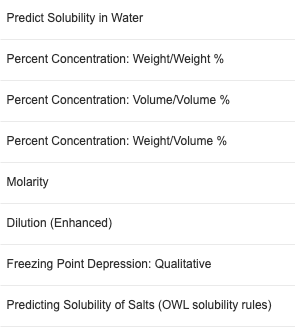

# **Chapter 09**

## *Chemical Reactions*

[Cengage Chapter 9 Link on Canvas](https://bridgeport.instructure.com/courses/2177365/modules/items/46775398)

[Lecture ppt slides link](https://drive.google.com/file/d/1UO5EAiQkc71uboacHWNy41FDTTKbIlZx/view?usp=sharing)

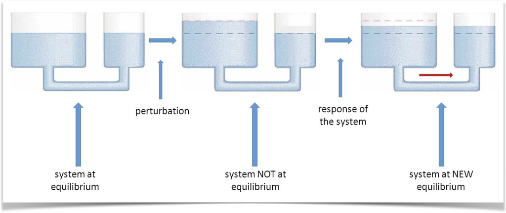

- **Types of Chemical Reactions**. Be able to classify a chemical reaction as a combination, decomposition, displacement, exchange or combustion reaction.
- **Reduction-Oxidation (Redox) Reactions**. Understand the defining characteristic of a redox reaction. Be able to use oxidation numbers to determine if a reaction is a redox reaction or a nonredox reaction. If given a redox reaction, be able to determine the substance oxidized, the substance reduced, the oxidizing agent, and the reducing agent.
- **Exothermic and Endothermic Reactions**. Know what is meant by the terms exothermic and endothermic. Be able to identify a reaction as exothermic or endothermic from an energy diagram graph.
- **Factors that Influence Chemical Reaction Rates**. Know the three basic factors which influence the rate of chemical reactions.
- **Chemical Equilibrium**. Understand the concepts of chemical equilibrium and equilibrium constant. Know how to write an equilibrium constant expression and calculate the value of the equilibrium constant. Be able to interpret the magnitude of the equilibrium constant to predict the relative completeness of the reaction at equilibrium.
- **Le Chatelier’s Principle**. Understand the basic idea of Le Chatelier’s principle and be able to apply it to predict the effects of changes in reactant/product concentrations, temperature, and catalyst addition on a chemical equilibrium.

## **Concept Check and/or Class Practice**

- Identify the category of the following reaction. 4HNO<sub>3</sub> ---> 4NO<sub>2</sub> + 2H<sub>2</sub>O + O<sub>2</sub> (a) Combination reaction (b) Decomposition reaction (c) Single-replacement reaction (d) Double-replacement reaction
- Classify each of the following chemical reactions as a combination, decomposition, displacement, exchange, or combustion reaction.

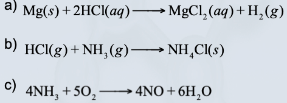

- Find the oxidation numbers for each of the elements in each of the following compounds: (a) K<sub>2</sub>Cr<sub>2</sub>O<sub>7</sub> (b) CO<sub>3</sub>2- (c) MnO<sub>2</sub> (d) PCl<sub>5</sub> (e) SF<sub>4</sub> (d) H<sub>2</sub>SO<sub>4</sub>
- In the reaction stated below, what is oxidized and what acts as the reducing agent? Cu + 2AgNO<sub>3</sub> ----> 2Ag + Cu(NO<sub>3</sub>)<sub>2</sub> (a) Cu is oxidized, and Cu is the reducing agent. (b) Cu is oxidized, and AgNO3 is the reducing agent. (c) Ag is oxidized, and Cu is the reducing agent. (d) Ag is oxidized, and AgNO3 is the reducing agent.
- In following reaction which is reduced ? Cd + Ni<sup>4+</sup> ---> Cd<sup>2+</sup> + Ni<sup>2+</sup> (a) Cd (b) Ni<sup>4+</sup> (c) Cd<sup>2+</sup> (d) Ni<sup>2+</sup>
- What are the three factors necessary for a chemical reaction to occur? (a) Proper temperature, pressure, and concentration (b) Proper temperature, pressure, and low activation energy (c) Proper temperature, low activation energy, and proper orientation of colliding particles (d) Molecular collisions, low activation energy, and proper orientation of particles
- Which of the following statement(s) is(are) correct? (a) During an exothermic reaction, the average energy of the products is higher than the average energy of the reactants. (b) During an endothermic reaction, the average energy of the products is lower than the average energy of the reactants. (c )During an exothermic reaction, the average energy of the products is lower than the average energy of the reactants. (d )Both (a) and (b).
- What is the function of a catalyst in a chemical reaction? (a) It increases the rate of the reaction by increasing the activation energy. (b) It increases the rate of the reaction by decreasing the activation energy. (c) It decreases the rate of the reaction by increasing the activation energy. (d) It decreases the rate of the reaction by decreasing the activation energy.
- A state of _____ is reached when the concentrations of all reactants and all products remain constant, and a _____ is one in which the conversion of reactants to products and the conversion of products to reactants occur simultaneously. (a) physical equilibrium; chemical equilibrium (b) chemical equilibrium; reversible reaction (c) reversible equilibrium; chemical reaction (d) reversible equilibrium; reversible reaction
- What factors affect the equilibrium of a reaction according to Le Châtelier’s principle? (a) Concentration, temperature, and catalyst (b) Temperature, pressure, and catalyst (c) Concentration, temperature, and pressure (d) Concentration, pressure, and catalyst
- In following reaction if reactant H<sub>2</sub> increase, reaction shift H<sub>2</sub> + I<sub>2</sub> ----> 2HI (a) left (b) right (c) none

### [**Cengage Chapter 9 electronic online h.w. on Canvas topics**:](https://bridgeport.instructure.com/courses/2177365/modules/items/46775416)

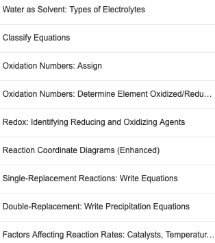

# **Chapter 10**

## *Acids, Bases, and Salts*

[Cengage Chapter 10 Link on Canvas](https://bridgeport.instructure.com/courses/2177365/modules/items/46775400)

[Lecture ppt slides link](https://drive.google.com/file/d/16hh_iKqM_qEqsE5-hBRVjgj0FWjQxuZF/view?usp=sharing)

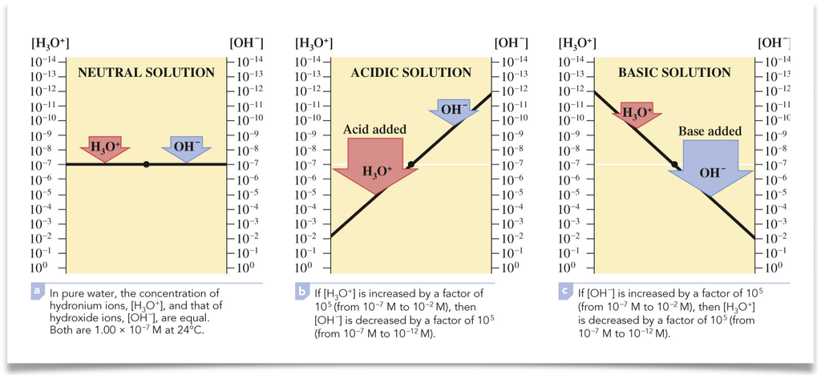

- **Acid-Base Definitions**. Be able to use the Arrhenius definition to recognize an acid or a base from their chemical formula. Be able to use the Brønsted-Lowry definition to identify the acid, the base, the conjugate acid, and the conjugate base of an acid-base reaction. Know what an amphoteric or amphiprotic substance is.
- **Strengths of Acids and Bases**. Understand what is meant by the terms strong and weak when applied to acids and bases. Be able to use the acid and conjugate base strength and acid (or base) strength.
- **Self-ionization of water and pH**. Understand how water can self-ionize into H3O+ and OH- ions and that Kw = 1.0×10-14 is the equilibrium constant for this reaction. Be able to use Kw to perform basic calculations to find [H<sub>3</sub>O<sup>+</sup>] and [OH<sup>-</sup>]. Understand the definitions of acidic, basic, and neutral.
- **pH**. Understand the pH concept, how to interpret pH values, and how to perform pH calculations.
- **Acid-base neutralization reactions**. Be able to write and balance an acid-base neutralization reaction.
- **Buffers**. Understand what a buffer solution is, how it can be prepared, and how it acts to prevent major changes in solution pH.
- **Electrolyte vs non-electrolyte**: Understand what molecule electrolyte and/or non-electrolyte.
- **Titrations**.Understand what a titration is and how to perform titration calculations.